# 2019 Ford Go-Bike Project

## by Ima Jackson

## Investigation Overview

The investigation on this dataset focuses on popular start and end stations of trips, trip duration patterns, trip weekly and hourly pattern, user_type and gender and the relationships that exist between them.

## Dataset Overview

There are 183,412 bike trips in this dataset with 16 features. Each row contains information on individual rides made in a bike-sharing system covering the greater San Francisco Bay area.

## Univariate Exploration

### Trip Distribution by Weekday

Thursday had the highest trips from the visual display. More trips were taken on weekdays than weekends.

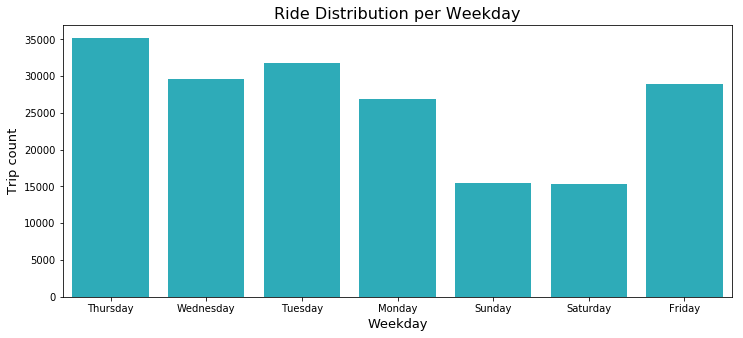

### Ride Distribution by Hour

The hour of the day with the highest record of trips is 5pm. Trips are more frequent between 7am -9am in the mornings, and 4pm - 6pm in the evenings, with a reduction of trips from 7pm - 7am in the morning.

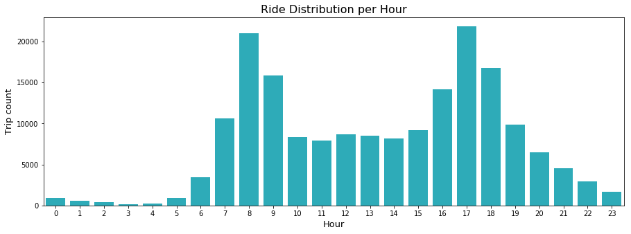

## Bivariate Exploration

### User Distribution of Trips by Weekday

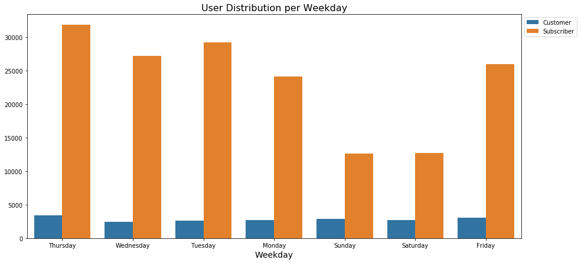

### Trip Duration Distribution of Users

Customers had higher trip duration time than subscribers, even though subscribers had more recorded trips..

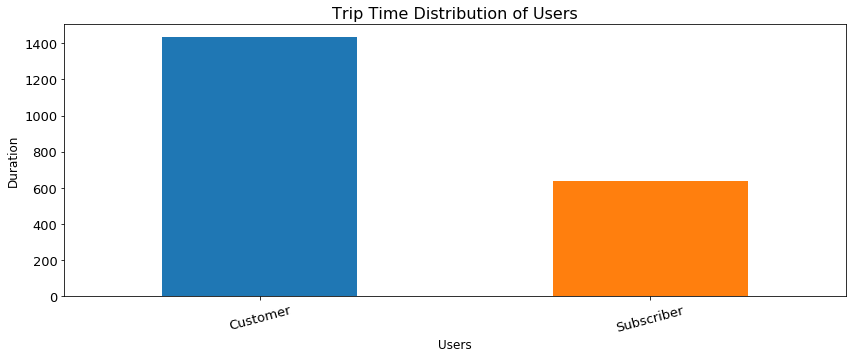

## Multivariate Exploration

### Trip Duration Distribution by Gender Usage

Male gender had the least trip time for both subscribers and users, though they had the highest record of trips.

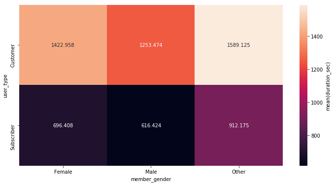

### Weekly Trip Duration of Users

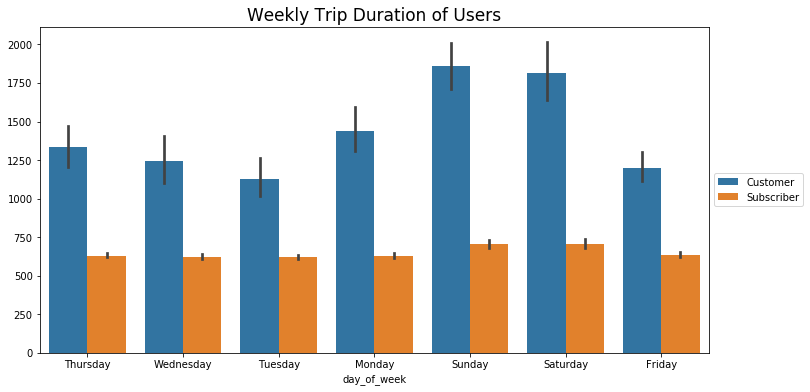